# week2

richard verbrugge

Sunday, March 15, 2015

# Reproducible Research: Peer Assessment 1

declare all required libs.

```r
setwd("C:/coursera/reproduce/week2")
library(plyr)
library(ggplot2)
library(lattice)
library(ggplot2)
```

```r
setwd("C:/coursera/reproduce/week2")
library(plyr)
library(ggplot2)
library(lattice)
library(ggplot2)
```

## Loading and preprocessing the data

### 1. Load the data (i.e. read.csv())

```r
setwd("C:/coursera/reproduce/week2")
unzip("activity.zip")
dataFile <- "activity.csv"
act <- read.csv(dataFile)
summary(act)
```

```
##      steps                date          interval
##  Min.   :  0.00   2012-10-01:  288   Min.   :   0.0
##  1st Qu.:  0.00   2012-10-02:  288   1st Qu.: 588.8
##  Median :  0.00   2012-10-03:  288   Median :1177.5
##  Mean   : 37.38   2012-10-04:  288   Mean   :1177.5
##  3rd Qu.: 12.00   2012-10-05:  288   3rd Qu.:1766.2
##  Max.   :806.00   2012-10-06:  288   Max.   :2355.0
##  NA's   :2304     (Other)   :15840
```

### 2. Process/transform the data (if necessary) into a format suitable for your analysis

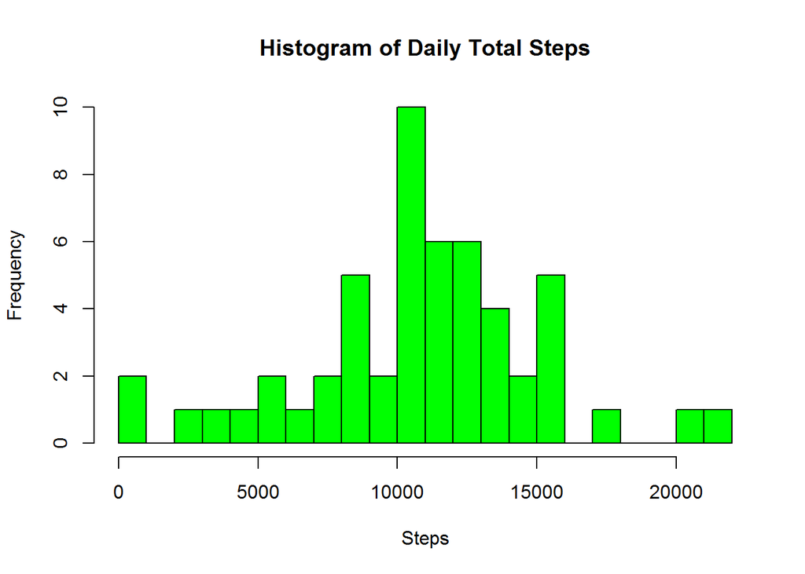

```r
actna <- na.omit(act)
result <- ddply(actna, .(date),
                summarise,
                steps = sum(steps, na.rm=TRUE)
)
hist(result$steps, breaks = 20, col = "green", main = "Histogram of Daily Total Steps", xlab = "Steps")
```

```r
# calculate mean and median
resultMean <- mean(result$steps, na.rm=TRUE)
resultMedian <- median(result$steps, na.rm=TRUE)
```

### 1. Make a time series plot of the 5-minute interval (x-axis) and the average number of steps taken, averaged across all days (y-axis)

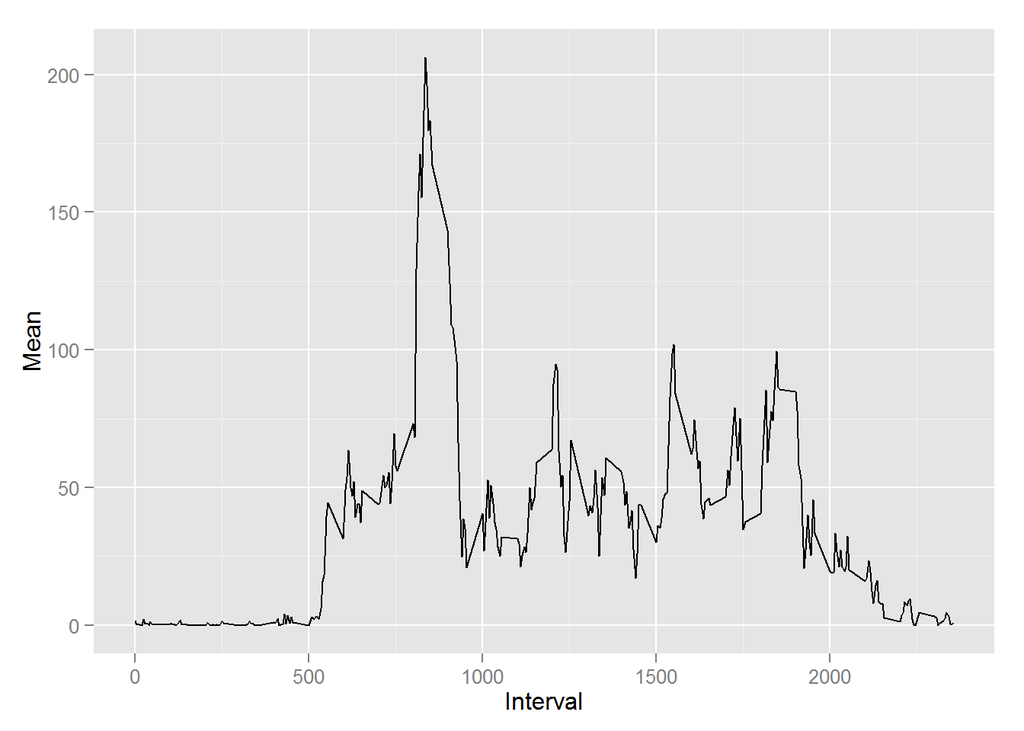

```r
# time series
actTS <- act
actTS$interval <- as.factor(actTS$interval)
interval_steps = aggregate(actTS[,1], by = list(actTS$interval), FUN = mean, na.rm=TRUE)
names(interval_steps) = c("Interval", "Mean")
interval_steps$Interval <- as.numeric(as.character(interval_steps$Interval))
ggplot(data=interval_steps, aes(x=Interval,y=Mean)) + geom_line()
```

### 2. Which 5-minute interval, on average across all the days in the dataset, contains the maximum number of steps?

```r
max <- interval_steps[which.max(interval_steps$Mean),]$Interval
max
```

```
## [1] 835
```

## Imputing missing values

### 1. Calculate and report the total number of missing values in the dataset (i.e. the total number of rows with NAs)

```r
mv <- with(act, sum(is.na(steps)))
mv
```

```
## [1] 2304
```

### 2. Devise a strategy for filling in all of the missing values in the dataset. The strategy does not need to be sophisticated. For example, you could use the mean/median for that day, or the mean for that 5-minute interval, etc.

My strategy is to replace each missing value, with the average step value for that interval.

```r
actMV <- act

for (i in 1:dim(actMV)[1]) {
  if (is.na(actMV[i,]$steps)) {
    interval = actMV[i,]$interval
    repl_value = interval_steps[interval_steps$Interval == interval,]$Mean
    actMV[i,]$steps = repl_value
  }
}
```

### 3. Create a new dataset that is equal to the original dataset but with the missing data filled in.

```r
actMV_date_steps = with(actMV, aggregate(x=steps, by=list(date), FUN=function(x) sum(x, na.rm=TRUE)))
```

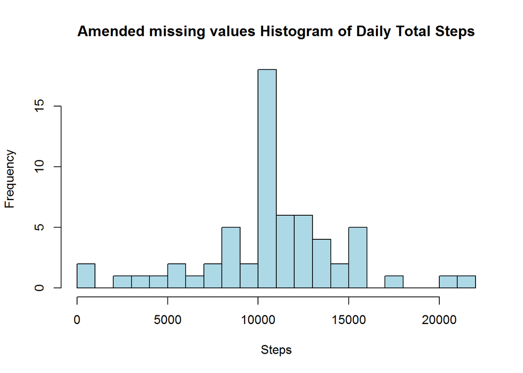

```r
hist(actMV_date_steps$x, breaks = 20, col = "lightblue", main = "Amended missing values Histogram of Daily Total Steps", xlab = "Steps")
```

## Are there differences in activity patterns between weekdays and weekends?

### 1. Create a new factor variable in the dataset with two levels – “weekday” and “weekend”

```r
act$dayType = weekdays( as.Date(act$date) )
weekends = (act$dayType == 'Saturday' | act$dayType == 'Sunday')

act$dayType = 'weekend'
act[!weekends,]$dayType = 'weekday'

act$dayType = as.factor(act$dayType)
```

### 2. Make a panel plot containing a time series plot (i.e. type = “l”) of the 5-minute interval (x-axis)

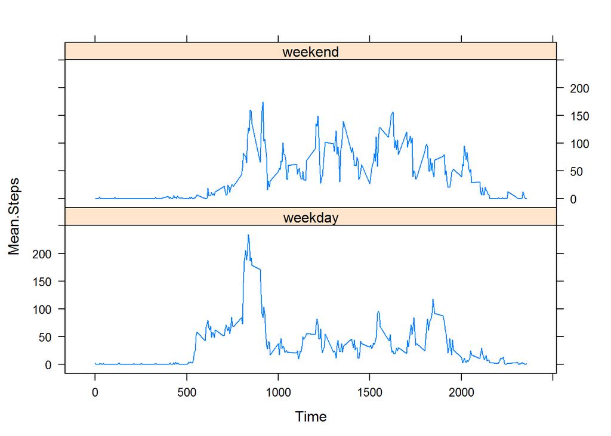

```r
steps_dayType = with(act, aggregate(x=steps, by=list(interval, dayType),
                                        FUN=function(x) mean(x, na.rm=T)))
names(steps_dayType) = c("Time", "dayType", "Mean.Steps")
xyplot(Mean.Steps ~ Time | dayType, data=steps_dayType, layout=c(1,2), type='l')
```